# **Môn học: TOÁN ỨNG DỤNG và THỐNG KÊ**

## **ĐỒ ÁN THỰC HÀNH CUỐI KỲ**

### Học kỳ 3, năm học 2023-2024; Lớp: **22CLC02-06**

### Câu 1: Data Fitting - Ngày 14/08/2024

# 1. Thông tin sinh viên

- Họ và tên: Nguyễn Gia Huy
- MSSV: 22127154
- Lớp: 22CLC06

# 2. Giới thiệu đề bài

**Data Fitting**: File `NHANES_age_prediction.csv` là bộ dữ liệu được thu thập vào năm 2013-2014 để đánh giá tình trạng sức khỏe và dinh dưỡng của người cao tuổi (từ 65 tuổi trở lên) và người trẻ (dưới 65 tuổi) tại Hoa Kỳ

Bộ dữ liệu có 2,278 dòng, mỗi dòng là thông tin của 1 người tham gia cuộc khảo sát và có 10 biến (xem mô tả các biến và tải bộ dữ liệu tại link: đây)

Bỏ qua biến `SEQN` (ID của người tham gia khảo sát) và biến `age_group` (nhóm tuổi mà người tham gia khảo sát thuộc về). Sau đó sử dụng phương pháp hồi quy tuyến tính để xây dựng mô hình dự báo bệnh tiểu đường (biến `DIQ010`) theo các yêu cầu sau:

- a. Sử dụng toàn bộ 7 biến đầu vào còn lại.
- b. Sử dụng duy nhất 1 biến cho kết quả tốt nhất.
- c. Xây dựng một mô hình của riêng bạn cho kết quả tốt nhất.

# 3. Ý tưởng thực hiện

- Bước 1: Đọc dữ liệu từ file `NHANES_age_prediction.csv`.
- Bước 2: Tiền xử lý dữ liệu: Loại bỏ biến `SEQN` và `age_group`.
- Bước 3: Chia dữ liệu thành 2 tập: tập huấn luyện và tập kiểm tra với các tỉ lệ khác nhau như: 40-60, 60-40, 80-20, 90-10.
- Bước 4: Xây dựng mô hình hồi quy tuyến tính với các yêu cầu đã nêu.
- Bước 5: Huấn luyện mô hình với tập huấn luyện.
- Bước 5: Đánh giá mô hình dựa trên MSE trên tập kiểm tra.
- Bước 6: Trực quan hóa kết quả.
- Bước 7: Kết luận.

**Lưu ý**:

- Để đảm bảo tính khách quan, em sẽ thực hiện các bước trên trên cả 6 tỉ lệ chia dữ liệu khác nhau. Đồng thời, với mỗi yêu cầu, ở mỗi tỉ lệ chia dữ liệu, em sẽ thực hiện 10 lần chạy mô hình để đánh giá độ ổn định của mô hình. Sau đó, em sẽ lấy giá trị trung bình của 10 lần chạy để tính trung bình MSE và trực quan hóa kết quả.
- Với trực quan hóa kết quả, vì việc vẽ biểu đồ để so sánh giá trị dự báo và giá trị thực tế của biến mục tiêu là không khả thi (vì có quá nhiều lần chạy, trung bình 1 model có thể chạy $6 * 10 = 60$), nên em sẽ vẽ biểu đồ so sánh `MSE` trung bình 10 lần chạy của mỗi model với mỗi tỉ lệ chia dữ liệu.
- Vì dữ liệu được xác trộn và được chia dữ liệu ngẫu nhiên, nên kết quả có thể thay đổi mỗi lần chạy. Điều này là tự nhiên và không thể tránh khỏi, giúp đánh giá độ ổn định của mô hình.
- Thời gian chạy mô hình có thể mất nhiều thời gian, tùy thuộc vào cấu hình máy tính của mỗi người.
  - Tổng thời gian chạy 3 yêu cầu của em với 4 mô hình, 6 tỉ lệ chia, 1 lần chạy và không xáo trộn dữ liệu là khoảng 1 phút 30 giây. (kết quả không đổi qua các lần chạy, output đã được lưu trong file `22127154_cau1_nonshuffle.html`)
  - Tổng thời gian chạy 3 yêu cầu của em với 4 mô hình, 6 tỉ lệ chia, 10 lần chạy và xáo trộn dữ liệu là khoảng gần 11 phút. (Kết quả có thể thay đổi qua các lần chạy, output đã được lưu trong file `22127154_cau1_10shuffle.html`).

Bên dưới là các biến global để tùy chỉnh cho việc thực hiện các bước trên:

- `split_ratios`: Tỉ lệ chia dữ liệu thành 2 tập (tập huấn luyện và tập kiểm tra). Ví dụ `[0.1, 0.2, 0.3, 0.4, 0.5, 0.6]` tương ứng với 6 tỉ lệ chia dữ liệu khác nhau.
- `shuffle`: Sử dụng để xác định việc trộn dữ liệu trước khi chia thành 2 tập hay không.
- `num_runs`: Số lần chạy mô hình để đánh giá độ ổn định của mô hình.
- `plot_result`: Sử dụng để xác định việc trực quan hóa kết quả hay không.
- `print_sub_table`: Sử dụng để in ra bảng kết quả chi tiết của từng model với mỗi tỉ lệ chia dữ liệu.

Vì thời gian chạy mô hình có thể mất nhiều thời gian, nên em sẽ đặt mặc định `shuffle = False`, `num_runs = 1`, `plot_result = True`, `print_sub_table = True` để giảm thời gian chạy mô hình. Để xem kết quả chi tiết của từng model, thầy cô có thể thay đổi các biến global trên hoặc tùy chỉnh trực tiếp ở từng model trong hàm `main()` ở phần **4.5.4. Hàm chính**.

```python
shuffle = False
split_ratios = [0.1, 0.2, 0.3, 0.4, 0.5, 0.6]
num_runs = 1
plot_result = True
print_sub_table = True
```

# 4. Thực hiện

## 4.1. Import thư viện cần thiết

Sau đây là các thư viện cần thiết cho quá trình thực hiện bài toán:

- `pandas`, `DataFrame`, `Series`: Đọc dữ liệu và xử lý dữ liệu. Cung cấp cấu trúc dữ liệu dạng DataFrame và Series để thao tác dữ liệu.
- `random`: Sử dụng để tạo ngẫu nhiên các số. Hỗ trợ việc xáo trộn dữ liệu.
- `math`: Cung cấp các hàm toán học cơ bản, sử dụng để tính toán giảm thiểu sai số.
- `itertools.combinations`: Hỗ trợ việc tạo ra tất cả các cặp hoặc tất cả các cách chọn k phần tử từ n phần tử.
- `matplotlib.pyplot`, `seaborn`: Hỗ trợ vẽ biểu đồ và trực quan hóa kết quả.
- `tabulate.tabulate`: Hỗ trợ in bảng kết quả dưới dạng bảng để tăng tính thẩm mỹ và dễ nhìn.
- `typing`: Hỗ trợ kiểm tra kiểu dữ liệu của biến và giúp code dễ đọc hơn.

```python
import pandas as pd
from pandas import DataFrame, Series
import random
import math
from itertools import combinations
import matplotlib.pyplot as plt
import seaborn as sns
from tabulate import tabulate
from typing import List, Tuple, Dict
```

## 4.2 Import các Package tự viết

Trong phần này, để dễ dàng mở rộng và tái sử dụng code, em sẽ import các package tự viết chứa các hàm cần thiết cho việc thực hiện bài toán.

- `matrix`: Chứa class `Matrix` do em tự viết, hỗ trợ việc tính toán ma trận như: cộng, trừ, nhân, chuyển vị, nghịch đảo, định thức, ...
- `model`: Chứa class `LinearRegression` do em tự viết, hỗ trợ việc huấn luyện mô hình hồi quy tuyến tính, dự báo, đánh giá mô hình dựa trên MSE, ... cùng các class con kế thừa từ class `LinearRegression` như `PolynomialRegression`, `RidgeRegression`, `LassoRegression`, `InteractionTermsRegression`, ... Package này sử dụng class `Matrix` để thực hiện các phép toán trên ma trận.

```python
from matrix import Matrix
from model import (
    LinearRegression,
    PolynomialRegression,
    InteractionTermsRegression,
    RidgeRegression,
    LassoRegression,
    ElasticNetRegression,
    BayesianLinearRegression,
)
```

## 4.3. Đọc dữ liệu và tiền xử lí dữ liệu

Trong phần này, em sẽ viết hàm đọc dữ liệu từ file `NHANES_age_prediction.csv` và tiền xử lý dữ liệu bằng cách loại bỏ biến `SEQN` và `age_group`. Kết quả trả về là DataFrame sau khi đã tiền xử lý và tập các đặc trưng (`features`)

```python
def load_data() -> Tuple[DataFrame, Series, List[str]]:
    """Load and preprocess the data.

    Returns:
        Tuple[DataFrame, Series, List[str]]: The feature matrix, target vector, and list of feature names.
    """
    data = pd.read_csv("NHANES_age_prediction.csv", delimiter=",")
    data = data.drop(columns=["SEQN", "age_group"]).dropna()

    features = [
        "RIDAGEYR",
        "RIAGENDR",
        "PAQ605",
        "BMXBMI",
        "LBXGLU",
        "LBXGLT",
        "LBXIN",
    ]
    target = "DIQ010"

    X: DataFrame = data[features]
    y: Series = data[target]

    return X, y, features
```

## 4.4. Chia dữ liệu thành 2 tập: tập huấn luyện và tập kiểm tra

Trong phần này, em sẽ viết hàm chia dữ liệu thành 2 tập: tập huấn luyện và tập kiểm tra với các tỉ lệ khác nhau như: 40-60, 60-40, 80-20, 90-10.

```python
def train_test_split(
    X: Matrix, y: Matrix, test_size: float = 0.2, shuffle: bool = True
) -> Tuple[Matrix, Matrix, Matrix, Matrix]:
    """Split the data into training and testing sets.

    Args:
        X (Matrix): Feature matrix.
        y (Matrix): Target matrix.
        test_size (float, optional): Proportion of the dataset to include in the test split. Defaults to 0.2.
        shuffle (bool, optional): Whether to shuffle the data before splitting. Defaults to True.

    Returns:
        Tuple[Matrix, Matrix, Matrix, Matrix]: The training and testing sets for both features and target.
    """
    indices = list(range(X.rows))

    if shuffle:
        random.shuffle(indices)

    test_indices = indices[: math.floor(test_size * len(indices))]
    train_indices = indices[math.floor(test_size * len(indices)) :]

    X_train = Matrix([X[i] for i in train_indices])
    y_train = Matrix([y[i] for i in train_indices])
    X_test = Matrix([X[i] for i in test_indices])
    y_test = Matrix([y[i] for i in test_indices])

    return X_train, X_test, y_train, y_test
```

### 4.4.1. Các hàm hỗ trợ

Trong phần này, em sẽ viết các hàm hỗ trợ cho việc đánh giá mô hình dựa trên MSE trên tập kiểm tra và trực quan hóa kết quả. Cụ thể:

- `evaluate_model`: Hàm đánh giá mô hình dựa trên MSE trên tập kiểm tra.
- `plot_result`: Hàm trực quan hóa kết quả.
- `format_result`: Hàm định dạng kết quả trung bình MSE của mô hình với mỗi tỉ lệ chia dữ liệu.

```python
def evaluate_model(
    model: LinearRegression,
    X_train: Matrix,
    y_train: Matrix,
    X_test: Matrix,
    y_test: Matrix,
) -> float:
    """Train the model and evaluate it using Mean Squared Error (MSE).

    Args:
        model (LinearRegression): The regression model to train.
        X_train (Matrix): The training feature matrix.
        y_train (Matrix): The training target matrix.
        X_test (Matrix): The testing feature matrix.
        y_test (Matrix): The testing target matrix.

    Returns:
        float: The Mean Squared Error (MSE) of the model on the test set.
    """
    model.fit(X_train, y_train)
    y_pred = model.predict(X_test)
    mse = model.mean_squared_error(y_test, y_pred)
    return mse


def format_results(results: Dict[str, List[float]]) -> DataFrame:
    """Format the results into a readable table format.

    Args:
        results (Dict[str, List[float]]): The results to format.

    Returns:
        DataFrame: A pandas DataFrame containing the formatted results.
    """
    formatted_results = pd.DataFrame(results).T

    # Based on global variables `split_ratios`, specify the columns to include in the table with name like "Test 10%"
    # formatted_results = formatted_results[split_ratios]
    formatted_results.columns = [f"Test {int(ratio * 100)}%" for ratio in split_ratios]

    return formatted_results


def plot_results(results: Dict[str, List[float]], title: str) -> None:
    """Visualize the results using seaborn.

    Args:
        results (Dict[str, List[float]]): The results to visualize.
        title (str): The title for the plot.
    """
    sns.set(style="whitegrid")
    df_results = format_results(results).reset_index()
    df_results = pd.melt(
        df_results, id_vars="index", var_name="Split Ratio", value_name="MSE"
    )

    plt.figure(figsize=(10, 6))
    sns.barplot(x="Split Ratio", y="MSE", hue="index", data=df_results)
    plt.title(title)
    plt.ylabel("Mean Squared Error")
    plt.xlabel("Train/Test Split Ratio")
    plt.legend(title="Model")
    plt.xticks(rotation=45)
    plt.tight_layout()
    plt.show()
```

## 4.5. Xây dựng mô hình hồi quy tuyến tính

Trong phần này, em sẽ xây dựng mô hình hồi quy tuyến tính với các yêu cầu đã nêu. Em đã xây dựng được một số mô hình như sau:

- `LinearRegression`: Mô hình hồi quy tuyến tính bậc nhất. $$y = w_0 + w_1x_1 + w_2x_2 + ... + w_nx_n$$
- `PolynomialRegression`: Mô hình hồi quy tuyến tính bậc cao. $$y = w_0 + w_1x_1 + w_2x_2^2 + ... + w_nx_n^n$$

Ví dụ: Với bậc 2, mô hình sẽ trở thành: $$y = w_0 + w_{11}x1 + w_{12}x1^2 + w_{21}x2 + w_{22}x2^2 + ... + w_{n1}x_n + w_{n2}x_n^2$$

Với bậc 3, mô hình sẽ trở thành: $$y = w_0 + w_{11}x^1 + w_{12}x_1^2 + w_{13}x_1^3 + w_{21}x_2 + w_{22}x_2^2 + w_{23}x_2^3 + ... + w_{n1}x_n + w_{n2}x_n^2 + w_{n3}x_n^3$$

- `InteractionTermsRegression`: Mô hình hồi quy tuyến tính với các biến tương tác. $$y = w_0 + w_1x_1 + w_2x_2 + ... + w_nx_n + w_{12}x_1x_2 + w_{13}x_1x_3 + ... + w_{1n}x_1x_n + w_{23}x_2x_3 + ... + w_{2n}x_2x_n + ... + w_{(n-1)n}x_{(n-1)}x_n$$
- `RidgeRegression`: Mô hình hồi quy tuyến tính với regularization L2. $$y = w_0 + w_1x_1 + w_2x_2 + ... + w_nx_n + \lambda \sum_{i=1}^{n}w_i^2$$
- `LassoRegression`: Mô hình hồi quy tuyến tính với regularization L1. $$y = w_0 + w_1x_1 + w_2x_2 + ... + w_nx_n + \lambda \sum_{i=1}^{n}|w_i|$$
- `ElasticNetRegression`: Mô hình hồi quy tuyến tính với regularization L1 và L2. $$y = w_0 + w_1x_1 + w_2x_2 + ... + w_nx_n + \lambda_1 \sum_{i=1}^{n}w_i^2 + \lambda_2 \sum_{i=1}^{n}|w_i|$$
- `BayesianRegression`: Mô hình hồi quy tuyến tính với phân phối Gaussian. $$y = w_0 + w_1x_1 + w_2x_2 + ... + w_nx_n + \epsilon, \epsilon \sim N(0, \sigma^2)$$

Tuy nhiên, trong quá trình chạy thử nghiệm, em thấy các mô hình `PolynomialRegression`, `LassoRegression`, `ElasticNetRegression` cho kết quả với sai số rất lớn, nên em sẽ không sử dụng mô hình này trong bài toán này.

```python
models = {
    "Linear Regression": LinearRegression(),
    # "Polynomial Regression (degree=2)": PolynomialRegression(degree=2),
    # "Polynomial Regression (degree=3)": PolynomialRegression(degree=3),
    "Interaction Terms Regression": InteractionTermsRegression(),
    "Ridge Regression": RidgeRegression(alpha=1.0),
    # "Lasso Regression": LassoRegression(alpha=1.0, max_iter=100),
    # "Elastic Net Regression": ElasticNetRegression(
    #     alpha=1.0, l1_ratio=0.5, max_iter=10
    # ),
    "Bayesian Linear Regression": BayesianLinearRegression(),
}
```

### 4.5.1. Xây dựng mô hình sử dụng toàn bộ 7 biến đầu vào còn lại

Trong phần này, em sẽ xây dựng mô hình hồi quy tuyến tính sử dụng toàn bộ 7 biến đầu vào còn lại. Ý tưởng chính là sử dụng class `LinearRegression` để huấn luyện mô hình và đánh giá mô hình dựa trên MSE trên tập kiểm tra.

Vòng lặp chính sẽ chạy qua từng tỉ lệ chia dữ liệu, với mỗi tỉ lệ chia dữ liệu, em sẽ chạy 10 lần mô hình để đánh giá độ ổn định của mô hình. Sau đó, em sẽ lấy giá trị trung bình của 10 lần chạy để tính trung bình MSE và trực quan hóa kết quả.

Bên dưới là code thực hiện việc xây dựng mô hình sử dụng toàn bộ 7 biến đầu vào còn lại và đánh giá mô hình dựa trên MSE trên tập kiểm tra với mô tả chi tiết.

```python
def run_models_with_different_splits(
    X: DataFrame,
    y: Series,
    split_ratios: List[float] = [0.1, 0.2, 0.4, 0.6],
    num_runs: int = 10,
    models: Dict[str, LinearRegression] = {
        "Linear Regression": LinearRegression(),
    },
    plot_result: bool = True,
    shuffle: bool = True,
    print_sub_table: bool = True,
) -> None:
    """Run models with different train/test splits and visualize the results.

    Args:
        X (DataFrame): The feature matrix.
        y (Series): The target vector.
        split_ratios (List[float], optional): List of split ratios to use. Defaults to [0.1, 0.2, 0.4, 0.6].
        num_runs (int, optional): Number of runs for each split. Defaults to 10.
        models (Dict[str, LinearRegression], optional): Dictionary of models to evaluate. Defaults to {"Linear Regression": LinearRegression()}.
        plot_result (bool, optional): Whether to plot the results. Defaults to True.
        shuffle (bool, optional): Whether to shuffle the data before splitting. Defaults to True.
        print_sub_table (bool, optional): Whether to print sub-tables for each model and split. Defaults to True.
    """
    if not shuffle:
        num_runs = 1
    X_list = X.to_numpy().tolist()
    y_list = y.to_numpy().tolist()
    X_matrix = Matrix(X_list)
    y_matrix = Matrix([y_list]).transpose()
    results = {model_name: [] for model_name in models}

    for split_ratio in split_ratios:
        table_data = []
        headers = ["Model", "Split Ratio", "MSE"]

        for model_name, model in models.items():
            # print(
            #     f"Running {model_name} with {int((1 - split_ratio) * 100)}/{int(split_ratio * 100)} train/test split..."
            # )
            mse_list = []
            for _ in range(num_runs):
                X_train, X_test, y_train, y_test = train_test_split(
                    X_matrix, y_matrix, test_size=split_ratio, shuffle=shuffle
                )
                mse = evaluate_model(model, X_train, y_train, X_test, y_test)
                mse_list.append(mse)

            avg_mse = sum(mse_list) / num_runs
            results[model_name].append(avg_mse)
            table_data.append(
                [
                    model_name,
                    f"{int((1 - split_ratio) * 100)}/{int(split_ratio * 100)}",
                    f"{avg_mse:.4f}",
                ]
            )
        if print_sub_table:
            print(tabulate(table_data, headers=headers, tablefmt="pretty"))

    formatted_results = format_results(results)

    # Plot the results for better visualization
    if plot_result:
        plot_results(
            results,
            "Mean Squared Error (MSE) across Different Models and Train/Test Splits",
        )

    # Tìm mô hình tốt nhất dựa trên MSE trung bình
    avg_results = {
        model_name: sum(mse_list) / len(mse_list)
        for model_name, mse_list in results.items()
    }
    best_model_name = min(avg_results, key=avg_results.get)

    print(
        f"=====> a) Best model: {best_model_name} with average MSE: {avg_results[best_model_name]:.4f}"
    )
```

### 4.5.2. Xây dựng mô hình sử dụng duy nhất 1 biến cho kết quả tốt nhất

Trong phần này, em sẽ xây dựng mô hình hồi quy tuyến tính sử dụng duy nhất 1 biến cho kết quả tốt nhất. Ý tưởng chính là sử dụng class `LinearRegression` để huấn luyện mô hình và đánh giá mô hình dựa trên MSE trên tập kiểm tra. Tuy nhiên, vì chỉ sử dụng duy nhất 1 biến nên mô hình `InteractionTermsRegression` sẽ không được sử dụng trong phần này.

Ý tưởng về vòng lặp chính và cách thức thực hiện tương tự như phần trước. Với mỗi đặc trưng, em sẽ lần lượt xây dựng mô hình và đánh giá mô hình dựa trên MSE trên tập kiểm tra. Cuối cùng, em sẽ chọn ra đặc trưng cho kết quả tốt nhất với mô hình.

Bên dưới là code thực hiện việc xây dựng mô hình sử dụng duy nhất 1 biến cho kết quả tốt nhất và đánh giá mô hình dựa trên MSE trên tập kiểm tra với mô tả chi tiết.

```python
def run_models_with_single_feature(
    X: DataFrame,
    y: Series,
    features: List[str],
    split_ratios: List[float] = [0.1, 0.2, 0.4, 0.6],
    num_runs: int = 10,
    models: Dict[str, LinearRegression] = {
        "Linear Regression": LinearRegression(),
    },
    plot_result: bool = True,
    shuffle: bool = True,
    print_sub_table: bool = True,
) -> None:
    """Run models with different train/test splits for each single feature.

    Args:
        X (DataFrame): The feature matrix.
        y (Series): The target vector.
        features (List[str]): List of feature names to evaluate individually.
        split_ratios (List[float], optional): List of split ratios to use. Defaults to [0.1, 0.2, 0.4, 0.6].
        num_runs (int, optional): Number of runs for each split. Defaults to 10.
        models (Dict[str, LinearRegression], optional): Dictionary of models to evaluate. Defaults to {"Linear Regression": LinearRegression()}.
        plot_result (bool, optional): Whether to plot the results. Defaults to True.
        shuffle (bool, optional): Whether to shuffle the data before splitting. Defaults to True.
        print_sub_table (bool, optional): Whether to print sub-tables for each model and split. Defaults to True.
    """
    if not shuffle:
        num_runs = 1
    models.pop(
        "Interaction Terms Regression", None
    )  # Remove model that requires multiple features
    y_list = y.to_numpy().tolist()
    y_matrix = Matrix([y_list]).transpose()

    final_results = {}

    for feature_idx, feature in enumerate(features):
        table_data = []
        headers = ["Model", "Feature", "Split Ratio", "MSE"]

        X_single_feature = X[feature]  # Only use one feature column
        X_list = X_single_feature.to_numpy().tolist()
        X_matrix = Matrix([X_list]).transpose()
        results = {model_name: [] for model_name in models}

        for split_ratio in split_ratios:
            for model_name, model in models.items():
                mse_list = []
                for _ in range(num_runs):
                    X_train, X_test, y_train, y_test = train_test_split(
                        X_matrix, y_matrix, test_size=split_ratio, shuffle=shuffle
                    )
                    mse = evaluate_model(model, X_train, y_train, X_test, y_test)
                    mse_list.append(mse)

                avg_mse = sum(mse_list) / num_runs
                results[model_name].append(avg_mse)
                table_data.append(
                    [
                        model_name,
                        feature,
                        f"{int((1 - split_ratio) * 100)}/{int(split_ratio * 100)}",
                        f"{avg_mse:.4f}",
                    ]
                )
        if print_sub_table:
            print(tabulate(table_data, headers=headers, tablefmt="pretty"))

        final_results[feature] = results

    # Plot results for each feature
    if plot_result:
        for feature, result in final_results.items():
            formatted_results = format_results(result)
            plot_results(result, f"Mean Squared Error (MSE) for {feature}")

    # Find the best model for each feature
    best_results = {}
    for feature, result in final_results.items():
        avg_results = {
            model_name: sum(mse_list) / len(mse_list)
            for model_name, mse_list in result.items()
        }
        best_model_name = min(avg_results, key=avg_results.get)
        best_results[feature] = (best_model_name, avg_results[best_model_name])

    summary_table = []
    for feature, (model_name, mse) in best_results.items():
        summary_table.append([feature, model_name, f"{mse:.4f}"])

    print(
        tabulate(
            summary_table, headers=["Feature", "Best Model", "MSE"], tablefmt="pretty"
        )
    )

    # Find the best overall feature and model
    best_feature = min(best_results, key=lambda x: best_results[x][1])
    best_model, best_mse = best_results[best_feature]
    print(
        f"\n=======> b) Best feature: {best_feature} | Best Model: {best_model} | MSE: {best_mse:.4f}"
    )
```

### 4.5.3. Xây dựng mô hình của riêng bạn cho kết quả tốt nhất

Trong phần này, em sẽ xây dựng mô hình của riêng mình cho kết quả tốt nhất. Ý tưởng chính là sử dụng class `LinearRegression` để huấn luyện mô hình và đánh giá mô hình dựa trên MSE trên tập kiểm tra với các tổ hợp đặc trưng khác nhau được tạo bởi `itertools.combinations`. Sẽ có tổng cộng $2^7 - 1 = 127$ tổ hợp đặc trưng khác nhau. Tuy nhiên, vì số lượng tổ hợp đặc trưng quá lớn nên thầy cô có thể tùy chỉnh việc in ra kết quả và biểu đồ trong mỗi lần chạy ở các tham số `print_sub_table` và `plot_result`.

Bên dưới là code thực hiện việc xây dựng mô hình của riêng bạn cho kết quả tốt nhất và đánh giá mô hình dựa trên MSE trên tập kiểm tra với mô tả chi tiết.

```python
def run_models_with_feature_combinations(
    X: DataFrame,
    y: Series,
    features: List[str],
    split_ratios: List[float] = [0.1, 0.2, 0.4, 0.6],
    num_runs: int = 10,
    models: Dict[str, LinearRegression] = {
        "Linear Regression": LinearRegression(),
    },
    plot_result: bool = True,
    shuffle: bool = True,
    print_sub_table: bool = True,
) -> None:
    """Run models with different train/test splits for all feature combinations.

    Args:
        X (DataFrame): The feature matrix.
        y (Series): The target vector.
        features (List[str]): List of feature names to combine and evaluate.
        split_ratios (List[float], optional): List of split ratios to use. Defaults to [0.1, 0.2, 0.4, 0.6].
        num_runs (int, optional): Number of runs for each split. Defaults to 10.
        models (Dict[str, LinearRegression], optional): Dictionary of models to evaluate. Defaults to {"Linear Regression": LinearRegression()}.
        plot_result (bool, optional): Whether to plot the results. Defaults to True.
        shuffle (bool, optional): Whether to shuffle the data before splitting. Defaults to True.
        print_sub_table (bool, optional): Whether to print sub-tables for each model and split. Defaults to True.
    """
    if not shuffle:
        num_runs = 1
    y_list = y.to_numpy().tolist()
    y_matrix = Matrix([y_list]).transpose()

    final_results = {}

    for r in range(
        1, len(features) + 1
    ):  # Generate all combinations from 1 to 7 features
        for combination in combinations(features, r):
            table_data = []
            headers = ["Model", "Feature Combination", "Split Ratio", "MSE"]

            if print_sub_table:
                print(f"\nEvaluating combination: {combination}")
            X_combination = X[
                list(combination)
            ]  # Only use the selected combination of features
            X_list = X_combination.to_numpy().tolist()
            X_matrix = Matrix(X_list)
            results = {model_name: [] for model_name in models}

            for split_ratio in split_ratios:
                for model_name, model in models.items():
                    mse_list = []
                    for _ in range(num_runs):
                        X_train, X_test, y_train, y_test = train_test_split(
                            X_matrix, y_matrix, test_size=split_ratio, shuffle=shuffle
                        )
                        mse = evaluate_model(model, X_train, y_train, X_test, y_test)
                        mse_list.append(mse)

                    avg_mse = sum(mse_list) / num_runs
                    results[model_name].append(avg_mse)
                    table_data.append(
                        [
                            model_name,
                            str(combination),
                            f"{int((1 - split_ratio) * 100)}/{int(split_ratio * 100)}",
                            f"{avg_mse:.4f}",
                        ]
                    )

            if print_sub_table:
                print(tabulate(table_data, headers=headers, tablefmt="pretty"))

            final_results[combination] = results

    # Plot results for each combination
    if plot_result:
        for combination, result in final_results.items():
            formatted_results = format_results(result)
            plot_results(result, f"Mean Squared Error (MSE) for {combination}")

    # Find the best model for each combination
    best_results = {}
    for combination, result in final_results.items():
        avg_results = {
            model_name: sum(mse_list) / len(mse_list)
            for model_name, mse_list in result.items()
        }
        best_model_name = min(avg_results, key=avg_results.get)
        best_results[combination] = (best_model_name, avg_results[best_model_name])

    # Print the best result for each combination
    summary_table = []
    for combination, (model_name, mse) in best_results.items():
        summary_table.append([str(combination), model_name, f"{mse:.4f}"])

    print(
        tabulate(
            summary_table,
            headers=["Combination", "Best Model", "MSE"],
            tablefmt="pretty",
        )
    )

    # Find the overall best combination
    best_combination = min(best_results, key=lambda x: best_results[x][1])
    best_model, best_mse = best_results[best_combination]
    print(
        f"\n========> c) Best combination: {best_combination} | Best Model: {best_model} | MSE: {best_mse:.4f}\n\n\n"
    )
```

### 4.5.4. Hàm chính

Cuối cùng, em sẽ viết hàm chính để thực hiện các yêu cầu đã nêu ở trên. Hàm này sẽ gọi lần lượt các hàm đã viết ở các phần trước để thực hiện các yêu cầu đã nêu.

Tuy nhiên, riêng hàm `run_models_with_feature_combinations`, em đặt mặc định là không in ra bảng kết quả chi tiết của từng model với mỗi tỉ lệ chia dữ liệu vì số lượng tổ hợp đặc trưng quá lớn. Thầy cô có thể chỉnh thông số `print_sub_table` để in ra bảng kết quả chi tiết và `plot_result` để in ra biểu đồ so sánh của từng model với mỗi tỉ lệ chia dữ liệu.

Bên dưới là code thực hiện việc thực hiện các yêu cầu đã nêu ở trên.

```
+------------------------------+-------------+--------+
|            Model             | Split Ratio |  MSE   |
+------------------------------+-------------+--------+
|      Linear Regression       |    90/10    | 0.0279 |
| Interaction Terms Regression |    90/10    | 0.0265 |
|       Ridge Regression       |    90/10    | 0.0286 |
|  Bayesian Linear Regression  |    90/10    | 0.0286 |
+------------------------------+-------------+--------+
+------------------------------+-------------+--------+
|            Model             | Split Ratio |  MSE   |
+------------------------------+-------------+--------+
|      Linear Regression       |    80/20    | 0.0378 |
| Interaction Terms Regression |    80/20    | 0.0384 |
|       Ridge Regression       |    80/20    | 0.0384 |
|  Bayesian Linear Regression  |    80/20    | 0.0384 |
+------------------------------+-------------+--------+
+------------------------------+-------------+--------+
|            Model             | Split Ratio |  MSE   |
+------------------------------+-------------+--------+
|      Linear Regression       |    70/30    | 0.0426 |
| Interaction Terms Regression |    70/30    | 0.0441 |
|       Ridge Regression       |    70/30    | 0.0430 |
|  Bayesian Linear Regression  |    70/30    | 0.0430 |
+------------------------------+-------------+--------+
+------------------------------+-------------+--------+
|            Model             | Split Ratio |  MSE   |
+------------------------------+-------------+--------+
|      Linear Regression       |    60/40    | 0.0405 |
| Interaction Terms Regression |    60/40    | 0.0430 |
|       Ridge Regression       |    60/40    | 0.0408 |
|  Bayesian Linear Regression  |    60/40    | 0.0408 |
+------------------------------+-------------+--------+
+------------------------------+-------------+--------+
|            Model             | Split Ratio |  MSE   |
+------------------------------+-------------+--------+
|      Linear Regression       |    50/50    | 0.0388 |
| Interaction Terms Regression |    50/50    | 0.0433 |
|       Ridge Regression       |    50/50    | 0.0393 |
|  Bayesian Linear Regression  |    50/50    | 0.0393 |
+------------------------------+-------------+--------+
+------------------------------+-------------+--------+
|            Model             | Split Ratio |  MSE   |
+------------------------------+-------------+--------+
|      Linear Regression       |    40/60    | 0.0371 |
| Interaction Terms Regression |    40/60    | 0.0405 |
|       Ridge Regression       |    40/60    | 0.0386 |
|  Bayesian Linear Regression  |    40/60    | 0.0386 |
+------------------------------+-------------+--------+
```

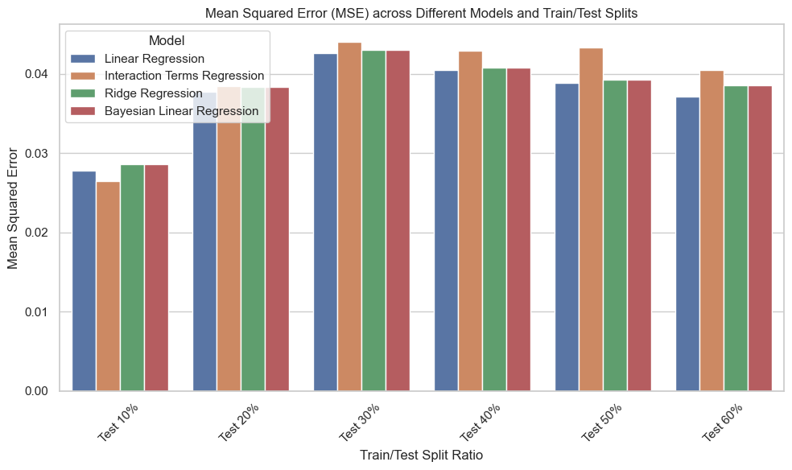

```
=====> a) Best model: Linear Regression with average MSE: 0.0375
+----------------------------+----------+-------------+--------+
|           Model            | Feature  | Split Ratio |  MSE   |
+----------------------------+----------+-------------+--------+
|     Linear Regression      | RIDAGEYR |    90/10    | 0.0275 |
|      Ridge Regression      | RIDAGEYR |    90/10    | 0.0275 |
| Bayesian Linear Regression | RIDAGEYR |    90/10    | 0.0275 |
|     Linear Regression      | RIDAGEYR |    80/20    | 0.0379 |
|      Ridge Regression      | RIDAGEYR |    80/20    | 0.0380 |
| Bayesian Linear Regression | RIDAGEYR |    80/20    | 0.0380 |
|     Linear Regression      | RIDAGEYR |    70/30    | 0.0425 |
|      Ridge Regression      | RIDAGEYR |    70/30    | 0.0426 |
| Bayesian Linear Regression | RIDAGEYR |    70/30    | 0.0426 |
|     Linear Regression      | RIDAGEYR |    60/40    | 0.0404 |
|      Ridge Regression      | RIDAGEYR |    60/40    | 0.0404 |
| Bayesian Linear Regression | RIDAGEYR |    60/40    | 0.0404 |
|     Linear Regression      | RIDAGEYR |    50/50    | 0.0384 |
|      Ridge Regression      | RIDAGEYR |    50/50    | 0.0385 |
| Bayesian Linear Regression | RIDAGEYR |    50/50    | 0.0385 |
|     Linear Regression      | RIDAGEYR |    40/60    | 0.0352 |
|      Ridge Regression      | RIDAGEYR |    40/60    | 0.0352 |
| Bayesian Linear Regression | RIDAGEYR |    40/60    | 0.0352 |
+----------------------------+----------+-------------+--------+
+----------------------------+----------+-------------+--------+
|           Model            | Feature  | Split Ratio |  MSE   |
+----------------------------+----------+-------------+--------+
|     Linear Regression      | RIAGENDR |    90/10    | 0.0270 |
|      Ridge Regression      | RIAGENDR |    90/10    | 0.0270 |
| Bayesian Linear Regression | RIAGENDR |    90/10    | 0.0270 |
|     Linear Regression      | RIAGENDR |    80/20    | 0.0374 |
|      Ridge Regression      | RIAGENDR |    80/20    | 0.0374 |
| Bayesian Linear Regression | RIAGENDR |    80/20    | 0.0374 |
|     Linear Regression      | RIAGENDR |    70/30    | 0.0422 |
|      Ridge Regression      | RIAGENDR |    70/30    | 0.0423 |
| Bayesian Linear Regression | RIAGENDR |    70/30    | 0.0423 |
|     Linear Regression      | RIAGENDR |    60/40    | 0.0404 |
|      Ridge Regression      | RIAGENDR |    60/40    | 0.0404 |
| Bayesian Linear Regression | RIAGENDR |    60/40    | 0.0404 |
|     Linear Regression      | RIAGENDR |    50/50    | 0.0385 |
|      Ridge Regression      | RIAGENDR |    50/50    | 0.0384 |
```

[output cut: 100 more lines]

```
|      Ridge Regression      |  LBXIN  |    80/20    | 0.0374 |
| Bayesian Linear Regression |  LBXIN  |    80/20    | 0.0374 |
|     Linear Regression      |  LBXIN  |    70/30    | 0.0423 |
|      Ridge Regression      |  LBXIN  |    70/30    | 0.0424 |
| Bayesian Linear Regression |  LBXIN  |    70/30    | 0.0424 |
|     Linear Regression      |  LBXIN  |    60/40    | 0.0403 |
|      Ridge Regression      |  LBXIN  |    60/40    | 0.0403 |
| Bayesian Linear Regression |  LBXIN  |    60/40    | 0.0403 |
|     Linear Regression      |  LBXIN  |    50/50    | 0.0385 |
|      Ridge Regression      |  LBXIN  |    50/50    | 0.0386 |
| Bayesian Linear Regression |  LBXIN  |    50/50    | 0.0386 |
|     Linear Regression      |  LBXIN  |    40/60    | 0.0352 |
|      Ridge Regression      |  LBXIN  |    40/60    | 0.0352 |
| Bayesian Linear Regression |  LBXIN  |    40/60    | 0.0352 |
+----------------------------+---------+-------------+--------+
```

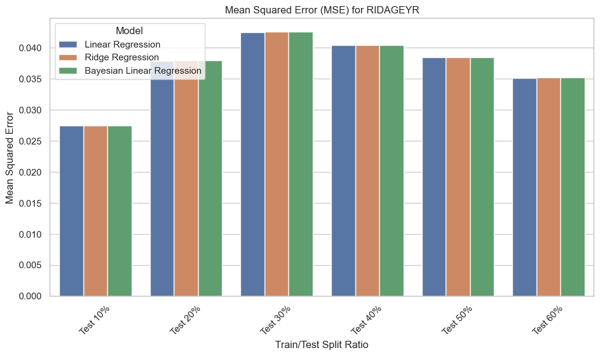

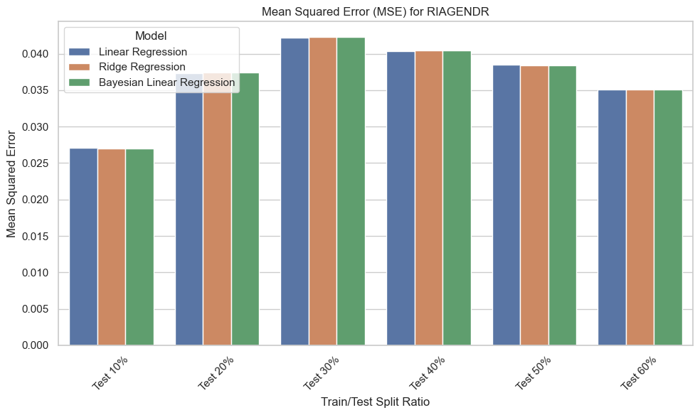

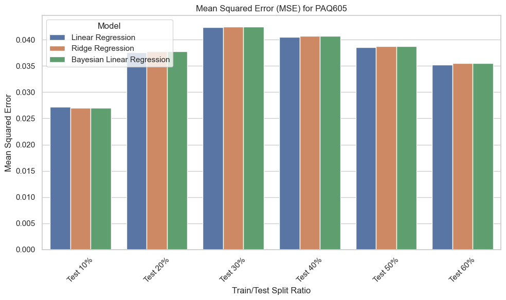

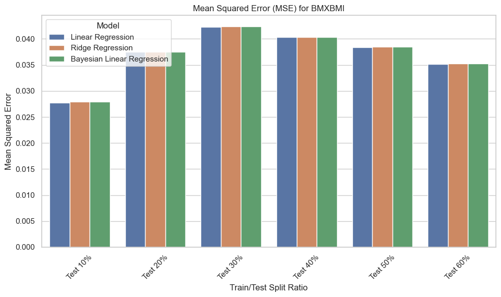

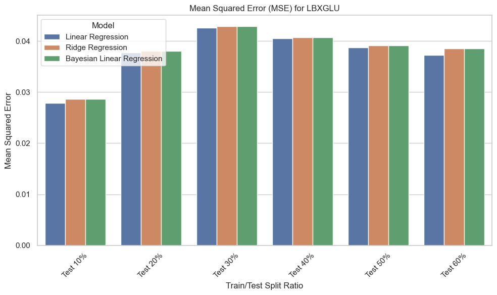

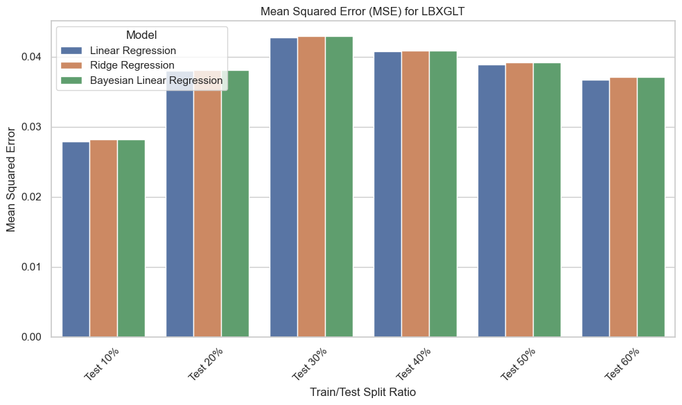

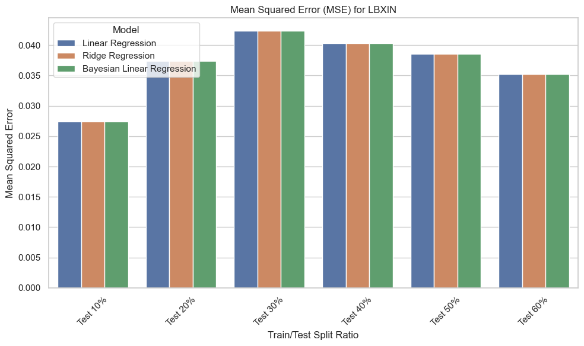

```
+----------+-------------------+--------+
| Feature  |    Best Model     |  MSE   |
+----------+-------------------+--------+
| RIDAGEYR | Linear Regression | 0.0370 |
| RIAGENDR | Linear Regression | 0.0368 |
|  PAQ605  | Linear Regression | 0.0369 |
|  BMXBMI  | Linear Regression | 0.0369 |
|  LBXGLU  | Linear Regression | 0.0374 |
|  LBXGLT  | Linear Regression | 0.0375 |
|  LBXIN   | Linear Regression | 0.0369 |
+----------+-------------------+--------+

=======> b) Best feature: RIAGENDR | Best Model: Linear Regression | MSE: 0.0368
+---------------------------------------------------------------------------+-------------------+--------+
|                                Combination                                |    Best Model     |  MSE   |
+---------------------------------------------------------------------------+-------------------+--------+
|                               ('RIDAGEYR',)                               | Linear Regression | 0.0370 |
|                               ('RIAGENDR',)                               | Linear Regression | 0.0368 |
|                                ('PAQ605',)                                | Linear Regression | 0.0369 |
|                                ('BMXBMI',)                                | Linear Regression | 0.0369 |
|                                ('LBXGLU',)                                | Linear Regression | 0.0374 |
|                                ('LBXGLT',)                                | Linear Regression | 0.0375 |
|                                ('LBXIN',)                                 | Linear Regression | 0.0369 |
|                         ('RIDAGEYR', 'RIAGENDR')                          | Linear Regression | 0.0369 |
|                          ('RIDAGEYR', 'PAQ605')                           | Linear Regression | 0.0370 |
|                          ('RIDAGEYR', 'BMXBMI')                           | Linear Regression | 0.0370 |
|                          ('RIDAGEYR', 'LBXGLU')                           | Linear Regression | 0.0375 |
|                          ('RIDAGEYR', 'LBXGLT')                           | Linear Regression | 0.0375 |
|                           ('RIDAGEYR', 'LBXIN')                           | Linear Regression | 0.0371 |
|                          ('RIAGENDR', 'PAQ605')                           | Linear Regression | 0.0368 |
|                          ('RIAGENDR', 'BMXBMI')                           | Linear Regression | 0.0368 |
|                          ('RIAGENDR', 'LBXGLU')                           | Linear Regression | 0.0374 |
|                          ('RIAGENDR', 'LBXGLT')                           | Linear Regression | 0.0375 |
|                           ('RIAGENDR', 'LBXIN')                           | Linear Regression | 0.0368 |
|                           ('PAQ605', 'BMXBMI')                            | Linear Regression | 0.0370 |
|                           ('PAQ605', 'LBXGLU')                            | Linear Regression | 0.0375 |
|                           ('PAQ605', 'LBXGLT')                            | Linear Regression | 0.0376 |
|                            ('PAQ605', 'LBXIN')                            | Linear Regression | 0.0369 |
|                           ('BMXBMI', 'LBXGLU')                            | Linear Regression | 0.0374 |
|                           ('BMXBMI', 'LBXGLT')                            | Linear Regression | 0.0375 |
```

[output cut: 91 more lines]

```
|            ('RIAGENDR', 'PAQ605', 'BMXBMI', 'LBXGLT', 'LBXIN')            | Linear Regression | 0.0375 |
|            ('RIAGENDR', 'PAQ605', 'LBXGLU', 'LBXGLT', 'LBXIN')            | Linear Regression | 0.0375 |
|            ('RIAGENDR', 'BMXBMI', 'LBXGLU', 'LBXGLT', 'LBXIN')            | Linear Regression | 0.0374 |
|             ('PAQ605', 'BMXBMI', 'LBXGLU', 'LBXGLT', 'LBXIN')             | Linear Regression | 0.0376 |
|     ('RIDAGEYR', 'RIAGENDR', 'PAQ605', 'BMXBMI', 'LBXGLU', 'LBXGLT')      | Linear Regression | 0.0376 |
|      ('RIDAGEYR', 'RIAGENDR', 'PAQ605', 'BMXBMI', 'LBXGLU', 'LBXIN')      | Linear Regression | 0.0373 |
|      ('RIDAGEYR', 'RIAGENDR', 'PAQ605', 'BMXBMI', 'LBXGLT', 'LBXIN')      | Linear Regression | 0.0374 |
|      ('RIDAGEYR', 'RIAGENDR', 'PAQ605', 'LBXGLU', 'LBXGLT', 'LBXIN')      | Linear Regression | 0.0374 |
|      ('RIDAGEYR', 'RIAGENDR', 'BMXBMI', 'LBXGLU', 'LBXGLT', 'LBXIN')      | Linear Regression | 0.0374 |
|       ('RIDAGEYR', 'PAQ605', 'BMXBMI', 'LBXGLU', 'LBXGLT', 'LBXIN')       | Linear Regression | 0.0375 |
|       ('RIAGENDR', 'PAQ605', 'BMXBMI', 'LBXGLU', 'LBXGLT', 'LBXIN')       | Linear Regression | 0.0375 |
| ('RIDAGEYR', 'RIAGENDR', 'PAQ605', 'BMXBMI', 'LBXGLU', 'LBXGLT', 'LBXIN') | Linear Regression | 0.0375 |
+---------------------------------------------------------------------------+-------------------+--------+

========> c) Best combination: ('RIAGENDR',) | Best Model: Linear Regression | MSE: 0.0368
```

```python
def main() -> None:
    """Main function to load data, run models, and visualize results."""
    X, y, features = load_data()

    # Run models and compare results with different train/test splits for all features
    run_models_with_different_splits(
        X,
        y,
        models=models,
        num_runs=num_runs,
        shuffle=shuffle,
        plot_result=plot_result,
        print_sub_table=print_sub_table,
        split_ratios=split_ratios,
    )

    # Run models and compare results with each single feature
    run_models_with_single_feature(
        X,
        y,
        features=features,
        models=models,
        num_runs=num_runs,
        shuffle=shuffle,
        plot_result=plot_result,
        print_sub_table=print_sub_table,
        split_ratios=split_ratios,
    )

    # Run models and compare results with all feature combinations
    run_models_with_feature_combinations(
        X,
        y,
        features=features,
        models=models,
        num_runs=num_runs,
        shuffle=shuffle,
        plot_result=False,
        print_sub_table=False,
        split_ratios=split_ratios,
    )


if __name__ == "__main__":
    main()
```

# 5. Kết luận

Sau quá trình thực hiện bài toán, em đã xây dựng mô hình hồi quy tuyến tính với các yêu cầu đã nêu. Đồng thời, em đã đánh giá mô hình dựa trên MSE trên tập kiểm tra và trực quan hóa kết quả, tìm ra được mô hình tốt nhất ứng với mỗi yêu cầu của đề bài. Kết quả mỗi lần chạy có thể thay đổi tùy thuộc vào nhiều yếu tố: việc chia dữ liệu ngẫu nhiên, việc xáo trộn dữ liệu, việc chọn mô hình, việc chọn đặc trưng, số lần chạy của một mô hình. Điều này là tự nhiên và không thể tránh khỏi. Tuy nhiên, việc chạy nhiều lần giúp đánh giá độ ổn định của mô hình và đưa ra kết luận chính xác hơn.

# 6. Tài liệu tham khảo

Trong quá trình thực hiện bài toán, em đã tham khảo một số tài liệu sau:

- [1] National Health and Nutrition Health Survey 2013-2014 (NHANES) Age Prediction Subset
- [2] [Polynomial Regression](https://www.geeksforgeeks.org/python-implementation-of-polynomial-regression/)
- [3] [Ridge Regression](https://phamdinhkhanh.github.io/deepai-book/ch_ml/index_RidgedRegression.html)
- [4] [Bayesian Regression](https://www.geeksforgeeks.org/implementation-of-bayesian-regression/)
- [5] [Pandas DataFrame](https://pandas.pydata.org/docs/reference/api/pandas.DataFrame.html)
- [6] [Pandas Series](https://pandas.pydata.org/docs/reference/api/pandas.Series.html)
- [7] [Matplotlib](https://matplotlib.org/stable/contents.html)
- [8] [Seaborn](https://seaborn.pydata.org/)
- [9] [Tabulate](https://pypi.org/project/tabulate/)